# 3 Data Visualization in Python

## 3.1 Introduction

This document demonstrates the use of the `plotnine` library in Python to visualize data via the *grammar of graphics* framework.

The functions in `plotnine` originate from the `ggplot2` R package, which is the R implementation of the grammar of graphics.

## 3.2 Grammar of Graphics

The *grammar of graphics* is a framework for creating data visualizations.

A visualization consists of:

- The **aesthetic**: Which *variables* are dictating which *plot elements*.
- The **geometry**: What *shape* of plot your are making.

```
<Figure Size: (640 x 480)>
```

The **aesthetic** is **species** on the x-axis, **bill_length_mm** on the y-axis, colored by **species**.

The **geometry** is a **boxplot**.

## 3.3 plotnine (i.e. ggplot)

The library `plotnine` implements the *grammar of graphics* in Python.

Code for the previous example:

````markdown
```{python}
#| eval: false
#| code-fold: show
(ggplot(penguins, aes(x = "species", y = "bill_length_mm", fill = "species"))
+ geom_boxplot()
)
```
````

### 3.3.1 The aesthetic:

````markdown
```{python}
(ggplot(penguins,
aes(                           # <1>
  x = "species",               # <2>
  y = "bill_length_mm",        # <2>
  fill = "species"))           # <2>
+ geom_boxplot()
)
```
````

[output not shown]

```
<Figure Size: (640 x 480)>
```

1. The `aes()` function is the place to specify aesthetics.
2. `x`, `y`, and `fill` are three possible aesthetics that can be specified, that map variables in our data set to plot elements.

### 3.3.2 The geometry

````markdown
```{python}
(ggplot(penguins,
aes(
  x = "species",
  y = "bill_length_mm",
  fill = "species"))
+ geom_boxplot() # <1>
)
```
````

[output not shown]

```
<Figure Size: (640 x 480)>
```

1. A variety of `geom_*` functions allow for different plotting shapes (e.g. boxplot, histogram, etc.)

### 3.3.3 Other optional elements:

- The *scales* of the x- and y-axes.
- The *color* of elements that are not mapped to aesthetics.
- The *theme* of the plot

…and many more!

### 3.3.4 Scales

````markdown
```{python}
(ggplot(penguins, aes(x = "species", y = "bill_length_mm", fill = "species"))
+ geom_boxplot()
)
```
````

[output not shown]

```
<Figure Size: (640 x 480)>
```

versus

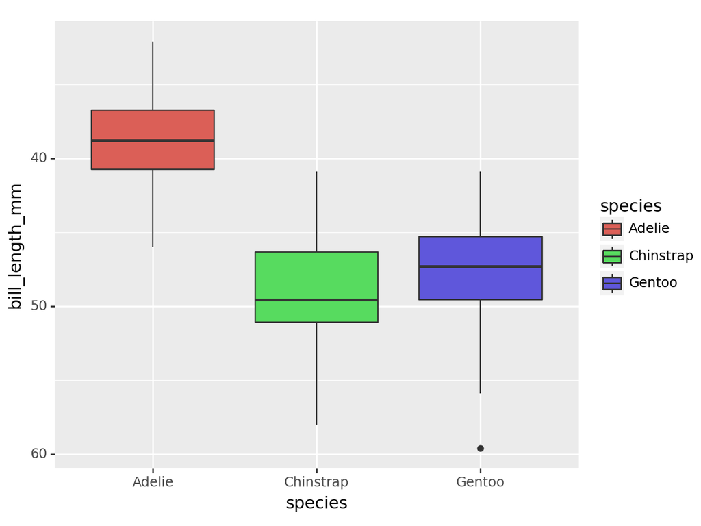

```
<Figure Size: (640 x 480)>
```

````markdown
```{python}
from plotnine import scale_y_reverse
(ggplot(penguins, aes(x = "species", y = "bill_length_mm", fill = "species"))
+ geom_boxplot()
+ scale_y_reverse()
)
```
````

### 3.3.5 Non-aesthetic colors

````markdown
```{python}
(ggplot(penguins, aes(x = "species", y = "bill_length_mm", fill = "species"))
+ geom_boxplot()
)
```
````

[output not shown]

```
<Figure Size: (640 x 480)>
```

versus

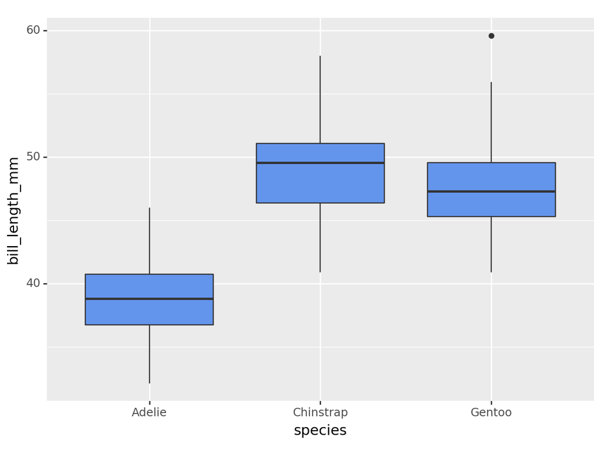

```
<Figure Size: (640 x 480)>
```

````markdown
```{python}
(ggplot(penguins, aes(x = "species", y = "bill_length_mm", fill = "species"))
+ geom_boxplot(fill = "cornflowerblue")
)
```
````

### 3.3.6 Quick quiz

What will this show?

````markdown
```{python}
#| eval: false

(ggplot(penguins,
aes(
  x = "species",
  y = "bill_length_mm",
  fill = "cornflowerblue"))
+ geom_boxplot()
)
```
````

### 3.3.7 Themes

````markdown
```{python}
(ggplot(penguins, aes(x = "species", y = "bill_length_mm", fill = "species"))
+ geom_boxplot()
)
```
````

[output not shown]

```
<Figure Size: (640 x 480)>
```

versus

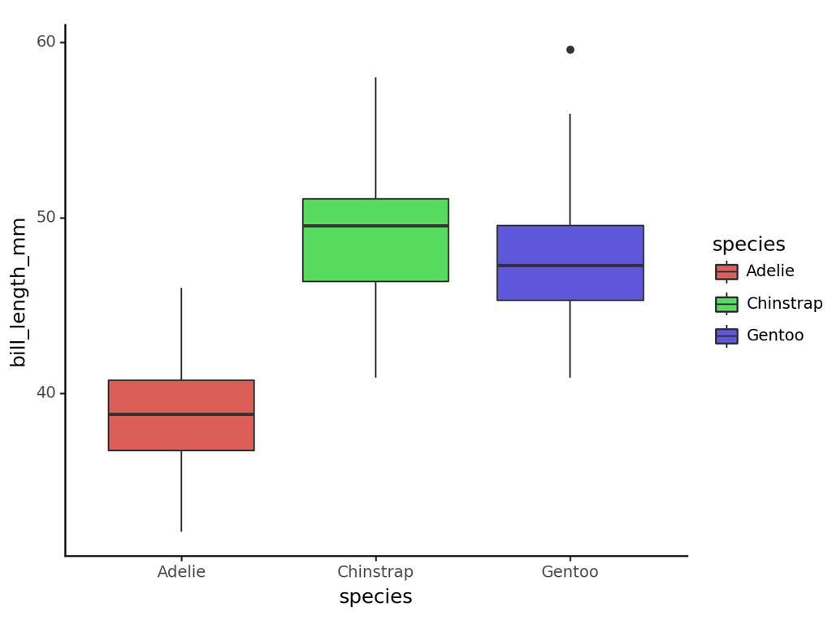

```
<Figure Size: (640 x 480)>
```

````markdown
```{python}
from plotnine import theme_classic
(ggplot(penguins, aes(x = "species", y = "bill_length_mm", fill = "species"))
+ geom_boxplot()
+ theme_classic()
)
```
````

### 3.3.8 Quick quiz

What are the *aesthetics*, *geometry*, *scales*, and other options?

### 3.3.9 Resources

- Scales: https://ggplot2-book.org/scale-position.html
- Themes: https://ggplot2-book.org/polishing.html

# 4 Geometries: The “Big Five”

### 4.0.1 1. Bar Plots

Most often used for showing **counts** of a **categorical variable**:

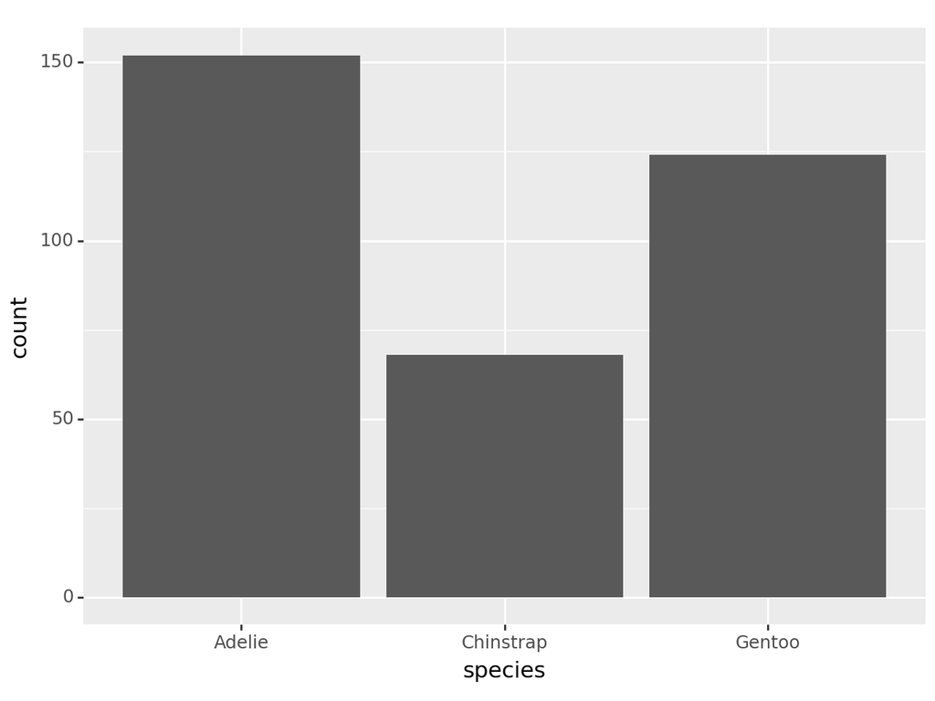

```
<Figure Size: (640 x 480)>
```

````markdown
```{python}
from plotnine import geom_bar
(ggplot(penguins,
aes(
  x = "species"
))
+ geom_bar()
)
```
````

… or **relationships** between **two categorical variables**:

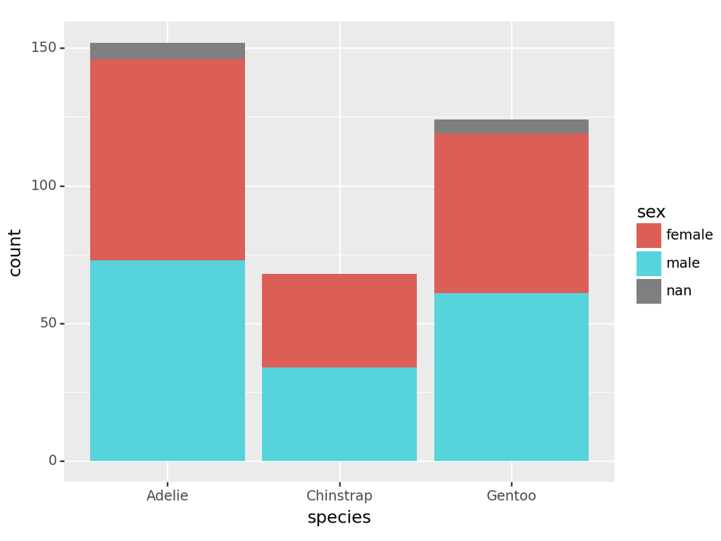

```
<Figure Size: (640 x 480)>
```

````markdown
```{python}
(ggplot(penguins,
aes(
  x = "species",
  fill = "sex"
))
+ geom_bar()
)
```
````

Would we rather see percents?

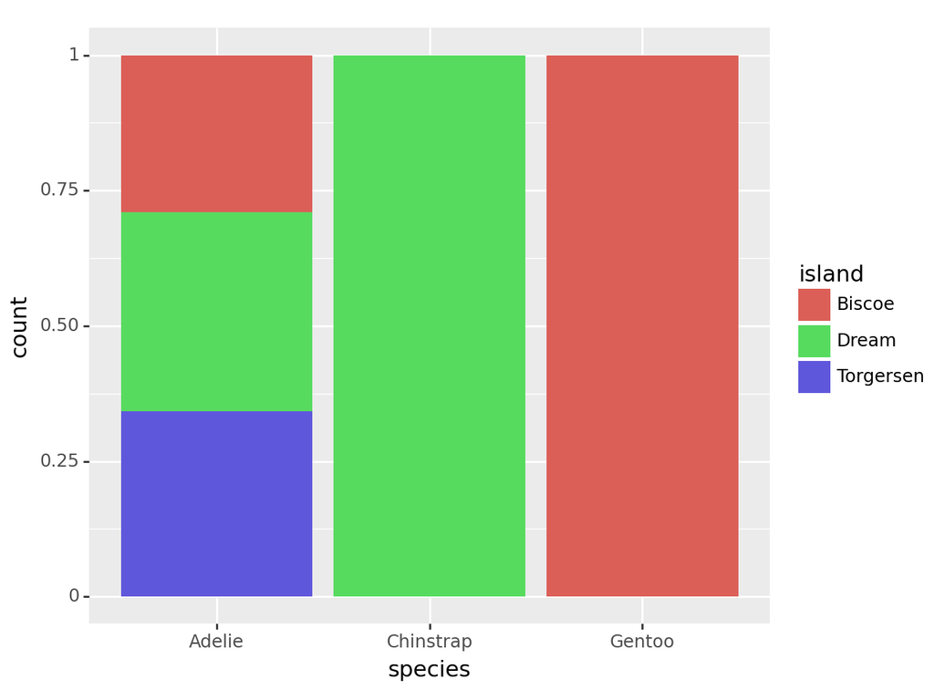

```
<Figure Size: (640 x 480)>
```

````markdown
```{python}
(ggplot(penguins,
aes(
  x = "species",
  fill = "island"
))
+ geom_bar(position = "fill")
)
```
````

Or side-by-side?

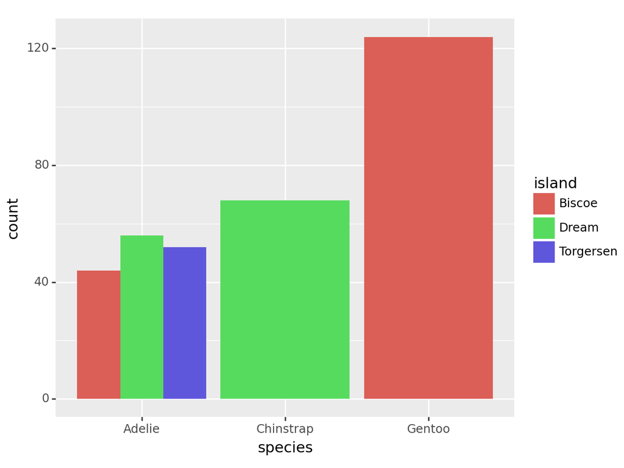

```
<Figure Size: (640 x 480)>
```

````markdown
```{python}
(ggplot(penguins,
aes(
  x = "species",
  fill = "island"
))
+ geom_bar(position = "dodge")
)
```
````

### 4.0.2 2. Boxplots

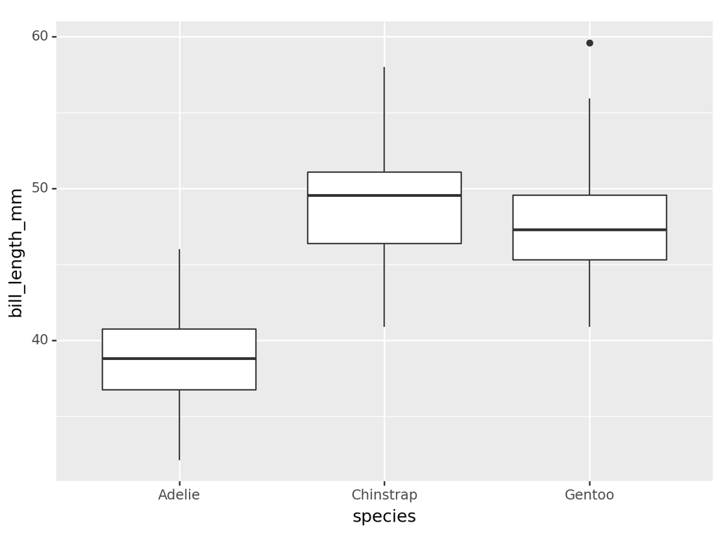

```
<Figure Size: (640 x 480)>
```

````markdown
```{python}
(ggplot(penguins,
aes(
  x = "species",
  y = "bill_length_mm"
))
+ geom_boxplot()
)
```
````

Side-by-side using a categorical variable:

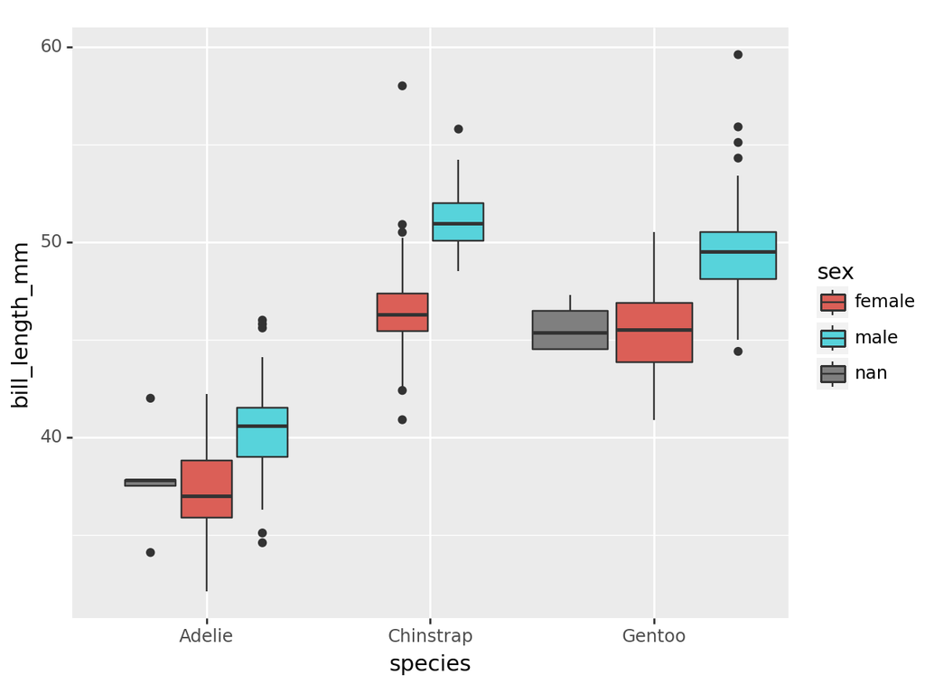

```
<Figure Size: (640 x 480)>
```

````markdown
```{python}
(ggplot(penguins,
aes(
  x = "species",
  y = "bill_length_mm",
  fill = "sex"
))
+ geom_boxplot()
)
```
````

### 4.0.3 3. Histograms

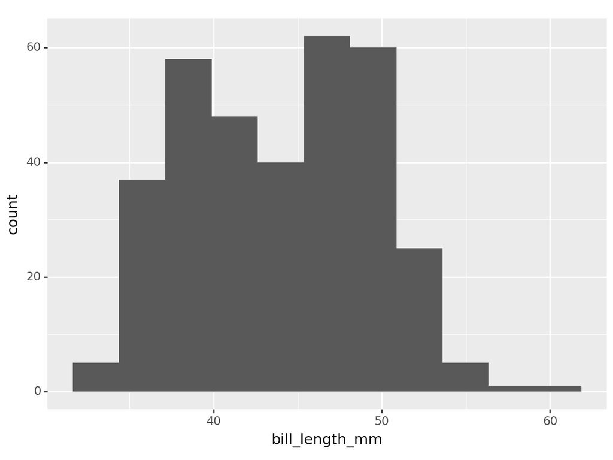

```
<Figure Size: (640 x 480)>
```

````markdown
```{python}
from plotnine import geom_histogram
(ggplot(penguins,
aes(
  x = "bill_length_mm"
))
+ geom_histogram()
)
```
````

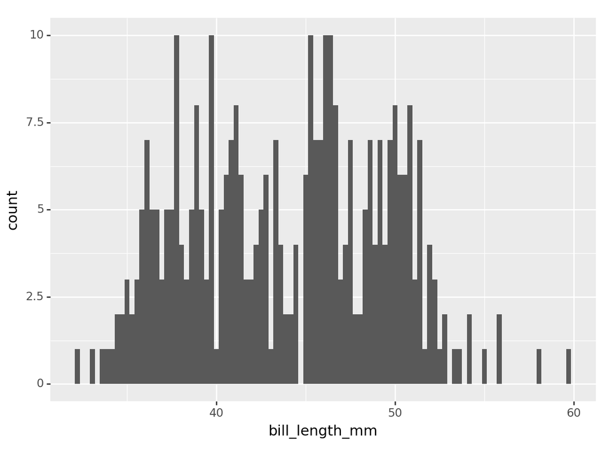

```
<Figure Size: (640 x 480)>
```

````markdown
```{python}
(ggplot(penguins,
aes(
  x = "bill_length_mm"
))
+ geom_histogram(bins = 100)
)
```
````

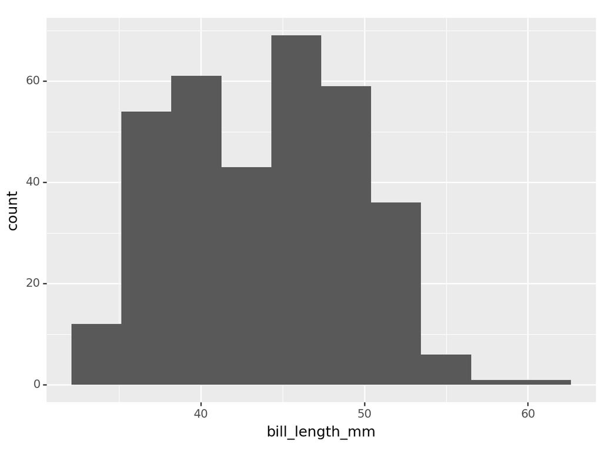

```
<Figure Size: (640 x 480)>
```

````markdown
```{python}
(ggplot(penguins,
aes(
  x = "bill_length_mm"
))
+ geom_histogram(bins = 10)
)
```
````

### 4.0.4 3.5 Densities

Suppose you want to compare histograms by **category**:

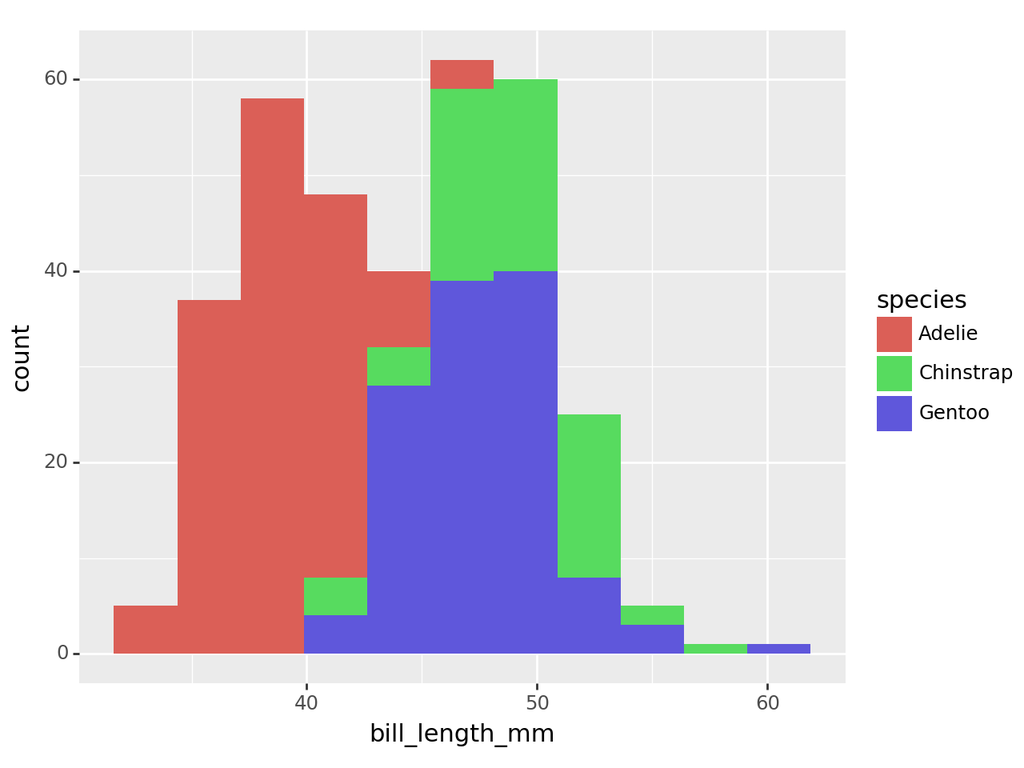

```
<Figure Size: (640 x 480)>
```

````markdown
```{python}
(ggplot(penguins,
aes(
  x = "bill_length_mm",
  fill = "species"
))
+ geom_histogram()
)
```
````

Cleaner: smoothed histogram, or density:

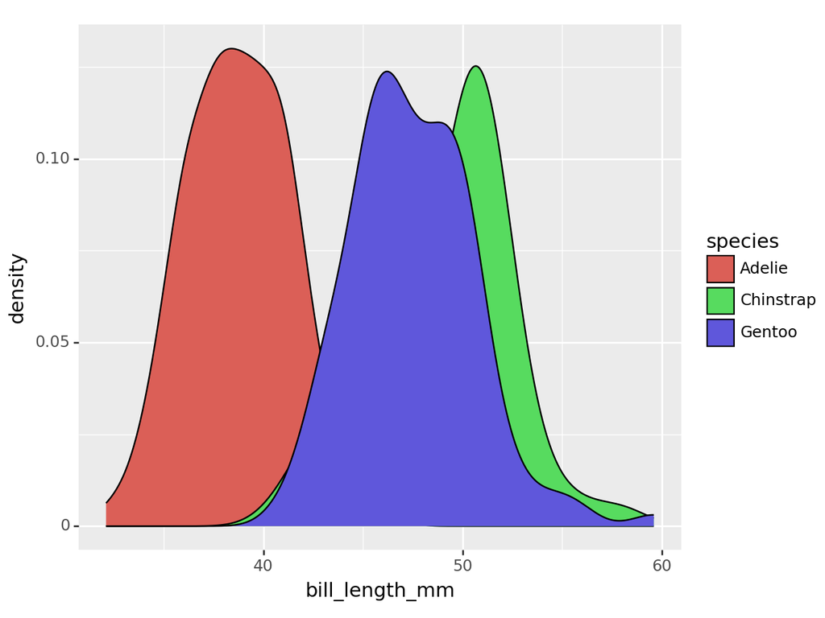

```
<Figure Size: (640 x 480)>
```

````markdown
```{python}
from plotnine import geom_density
(ggplot(penguins,
aes(
  x = "bill_length_mm",
  fill = "species"
))
+ geom_density()
)
```
````

Even cleaner: The **alpha** option:

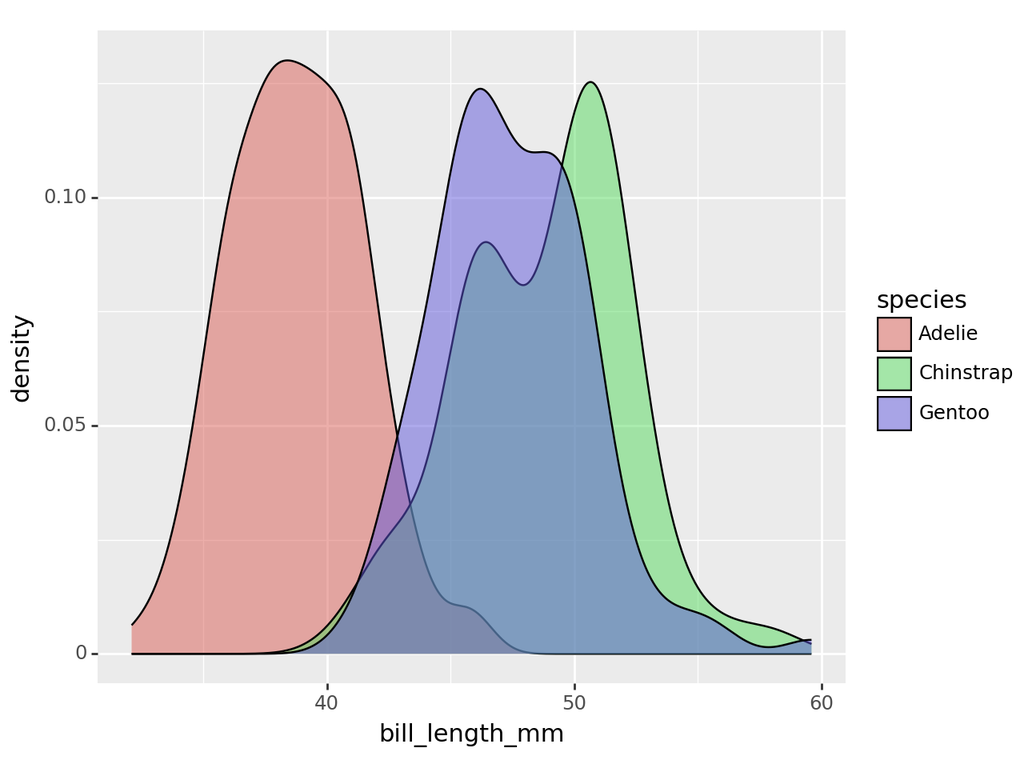

```
<Figure Size: (640 x 480)>
```

````markdown
```{python}
(ggplot(penguins,
aes(
  x = "bill_length_mm",
  fill = "species"
))
+ geom_density(alpha = 0.5)
)
```
````

### 4.0.5 4. Scatterplots

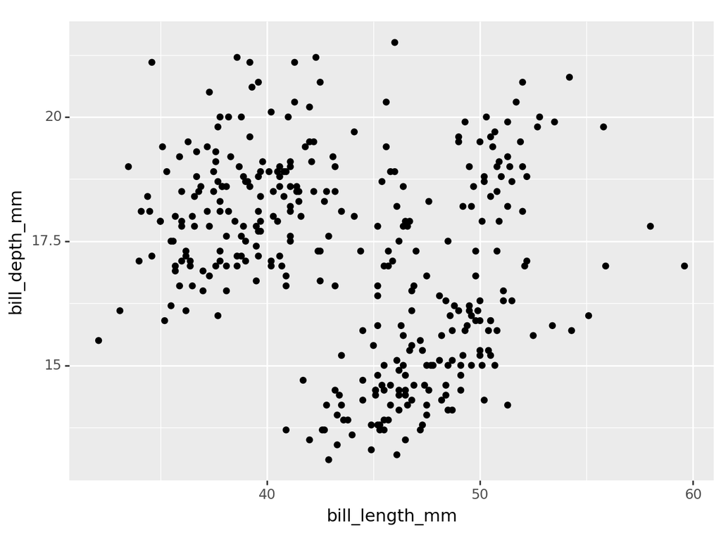

```
<Figure Size: (640 x 480)>
```

````markdown
```{python}
(ggplot(penguins,
aes(
  x = "bill_length_mm",
  y = "bill_depth_mm"
))
+ geom_point()
)
```
````

Colors for extra information:

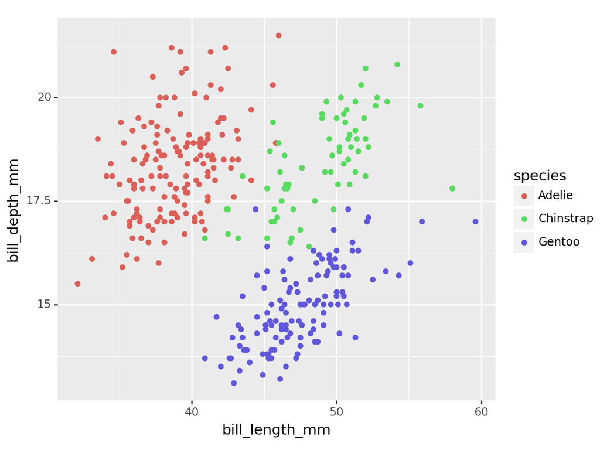

```
<Figure Size: (640 x 480)>
```

````markdown
```{python}
(ggplot(penguins,
aes(
  x = "bill_length_mm",
  y = "bill_depth_mm",
  color = "species"
))
+ geom_point()
)
```
````

### 4.0.6 5. Line Plots

````markdown
```{python}
from plotnine import geom_line
penguins2 = penguins.groupby(by = ["species", "sex"]).mean()

(ggplot(penguins2,
aes(
  x = "species",
  y = "bill_length_mm",
  color = "sex"
))
+ geom_point()
+ geom_line()
)
```
````

[output not shown]

[output not shown]

### 4.0.7 Resources

- `ggplot2` cheatsheet: https://www.rstudio.com/wp-content/uploads/2015/03/ggplot2-cheatsheet.pdf
- `plotnine`: https://plotnine.readthedocs.io/en/stable/

## 4.1 Multiple Plots

### 4.1.1 Facet Wrapping

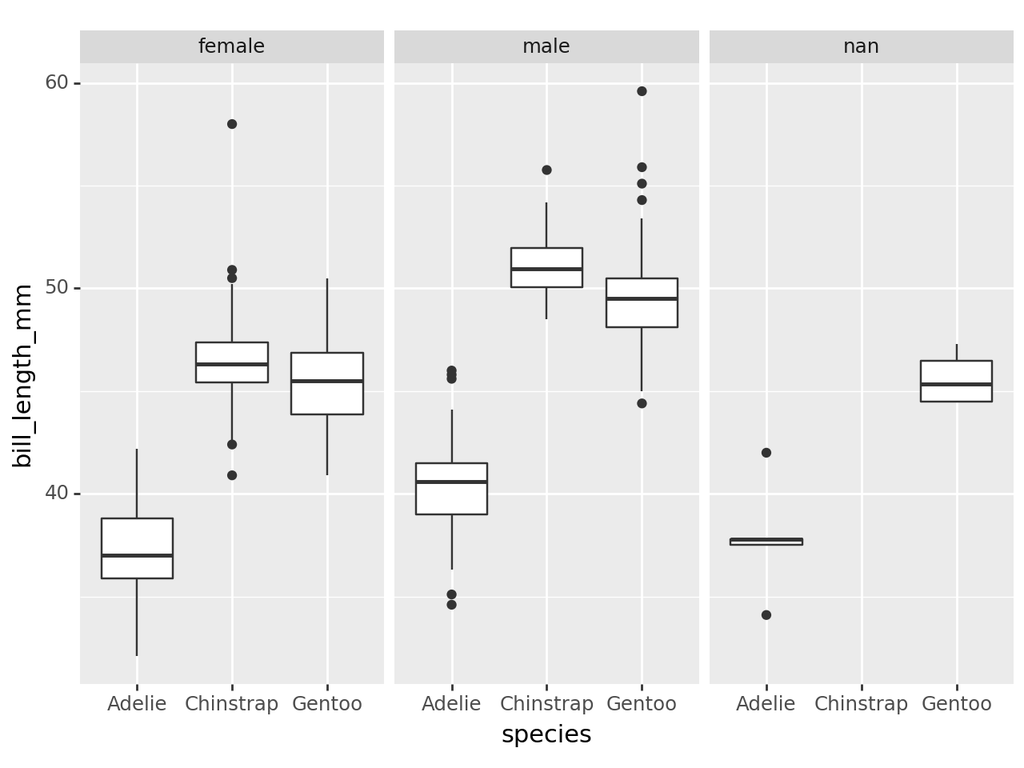

```
<Figure Size: (640 x 480)>
```

````markdown
```{python}
from plotnine import facet_wrap
(ggplot(penguins,
aes(
  x = "species",
  y = "bill_length_mm"
))
+ geom_boxplot()
+ facet_wrap("sex")
)
```
````